# Exploratory Data Analysis of Aadhaar Enrolment Data

# Top 10 Districts by Enrollment

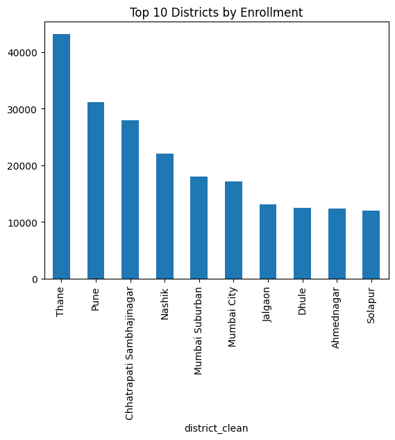

```python
top_districts = df.groupby('district_clean')['total_enrollment'] \
                  .sum().sort_values(ascending=False).head(10)

top_districts.plot(kind='bar')
plt.title('Top 10 Districts by Enrollment')
plt.show()
```

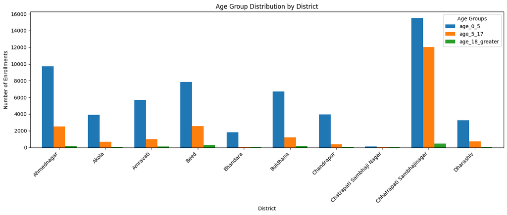

```python
import matplotlib.pyplot as plt

district_age = df.groupby('district_clean')[
    ['age_0_5','age_5_17','age_18_greater']
].sum().head(10)

ax = district_age.plot(
    kind='bar',
    stacked=False,      # important → no overlap
    figsize=(14,6),
    width=0.75
)

plt.title('Age Group Distribution by District')
plt.xlabel('District')
plt.ylabel('Number of Enrollments')
plt.xticks(rotation=45, ha='right')
plt.legend(title='Age Groups')
plt.tight_layout()
plt.show()
```

# 📊 Enrollment Variability Across Districts

This bar chart highlights the top 10 districts with the highest standard  
deviation in total enrollment, indicating significant variability over time. High volatility suggests  
inconsistent enrollment patterns, possibly due to seasonal drives, migration, or administrative factors.

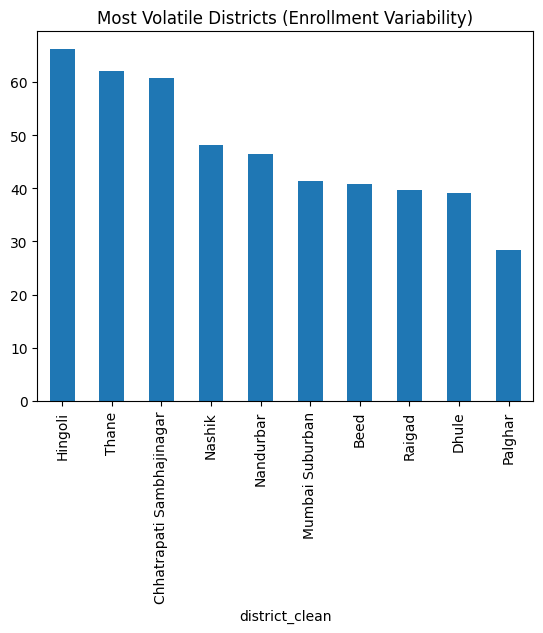

```python
district_std = df.groupby('district_clean')['total_enrollment'].std()

district_std.sort_values(ascending=False).head(10).plot(kind='bar')
plt.title('Most Volatile Districts (Enrollment Variability)')
plt.show()
```

# 📌 District-wise Enrollment Ranking Analysis

```python
district_rank = df.groupby('district_clean')['total_enrollment'].sum() \
                  .rank(ascending=False)

district_rank.sort_values().head(10)
```

```
district_clean
Thane                         1.0
Pune                          2.0
Chhatrapati Sambhajinagar     3.0
Nashik                        4.0
Mumbai Suburban               5.0
Mumbai City                   6.0
Jalgaon                       7.0
Dhule                         8.0
Ahmednagar                    9.0
Solapur                      10.0
Name: total_enrollment, dtype: float64
```

We performed univariate, bivariate, and multivariate analysis to study enrollment distribution across states,  
districts, and age groups. Advanced analysis included district-level volatility, age composition,  
time-based trends, and flag-based segmentation to uncover hidden patterns.